# Peeking into the Black Box

# 5 Model Explanations

The models are ready, so let’s shed light into them.

## 5.1 Setting up explainers

We start by setting up the explainers. These are basically objects that know how to create predictions.

**Crucial: the prediction function needs to work for subsets of datasets, not just for the original model data set.**

```r
fl_glm <- flashlight(
  model = fit_glm, label = "GLM",
  predict_function = function(fit, X) predict(fit, X, type = "response")
)

fl_nn <- flashlight(
  model = fit_nn, label = "NNet",
  predict_function = function(fit, X)
    predict(fit, prep_nn_calib(X, x), type = "response")
)

fl_xgb <- flashlight(
  model = fit_xgb, label = "XGBoost",
  predict_function = function(fit, X) predict(fit, prep_xgb(X, x))
)

# Combine them and add common elements like reference data
metrics <- list(`Average deviance` = deviance_poisson,
                `Relative deviance reduction` = r_squared_poisson)
fls <- multiflashlight(list(fl_glm, fl_nn, fl_xgb), data = test,
                       y = y, w = w, metrics = metrics)

# Version on canonical scale
fls_log <- multiflashlight(fls, linkinv = log)
```

## 5.2 Performance

We start to interpret the models by looking at model performance using deviance related metrics.

```r
fillc <- "#E69F00"

perf <- light_performance(fls)
perf
```

```
##
## I am an object with class(es) light_performance_multi, light_performance, light, list
##
## data.frames (maximum 6 rows shown):
##
##  data
## # A tibble: 6 x 3
##   label   metric                       value
##   <fct>   <fct>                        <dbl>
## 1 GLM     Average deviance            0.589
## 2 GLM     Relative deviance reduction 0.0261
## 3 NNet    Average deviance            0.582
## 4 NNet    Relative deviance reduction 0.0370
## 5 XGBoost Average deviance            0.577
## 6 XGBoost Relative deviance reduction 0.0452
```

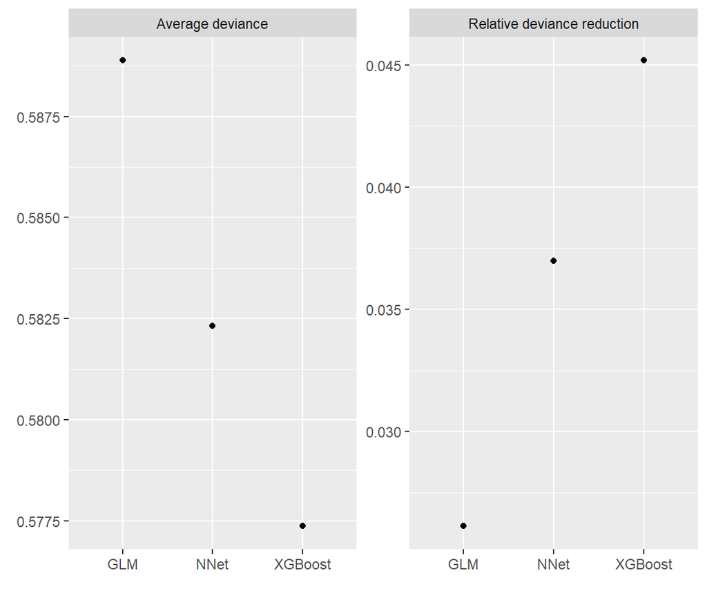

```r
plot(perf, geom = "point") +
  labs(x = element_blank(), y = element_blank())
```

## 5.3 Importance

Next, we consider permutation variable importance. By default `flashlight` uses the first performance metric specified above.

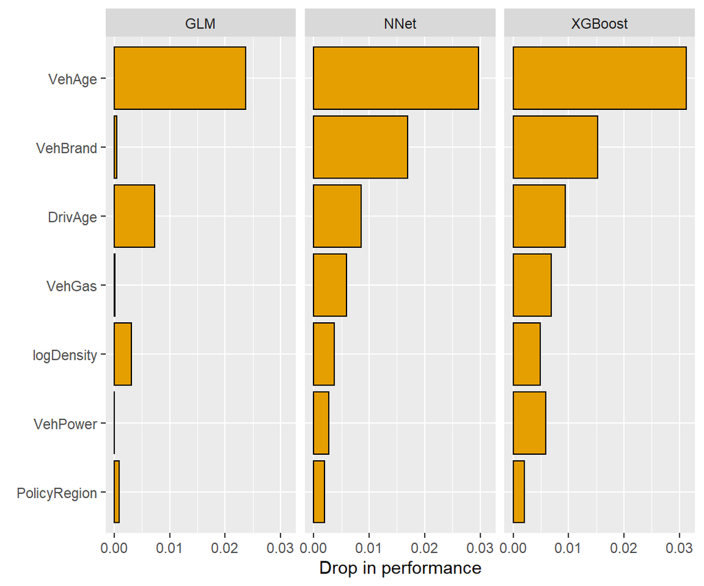

```r
imp <- light_importance(fls, v = x)
plot(imp, fill = fillc, color = "black")
```

## 5.4 Effects

Having identified the most important predictors, we would like to see how they act on the response. We consider different ways to investigate this.

### 5.4.1 ICE

Building block of partial dependence plots are individual conditional expectations. These show how predictions for single observations change when sliding the values of one covariable, keeping the rest fixed.

We show uncentered and centered ICE both on frequency and log-frequency scale.

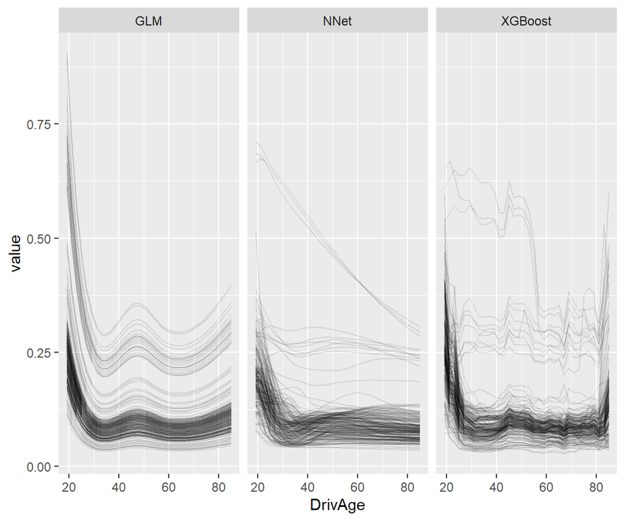

```r
# Frequency scale (uncentered)
plot(light_ice(fls, v = "DrivAge", n_max = 200, seed = 3), alpha = 0.1)
```

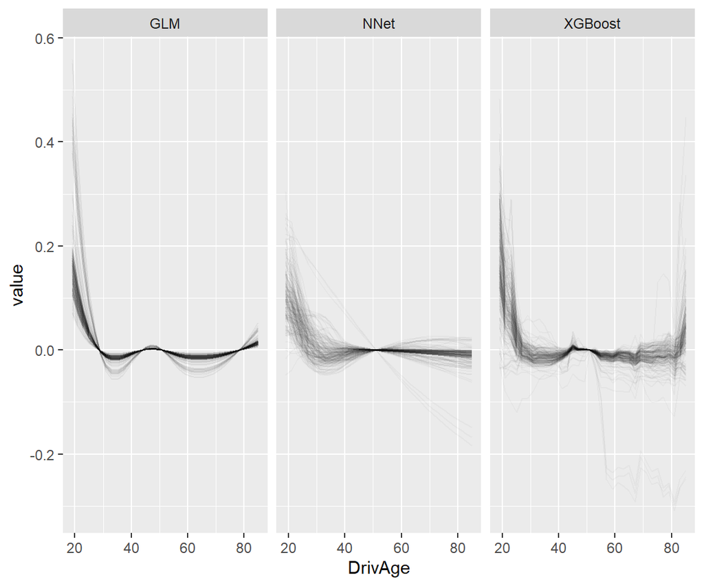

```r
# Frequency scale (centered)
plot(light_ice(fls, v = "DrivAge", n_max = 200, seed = 3,
               center = "middle"), alpha = 0.03)
```

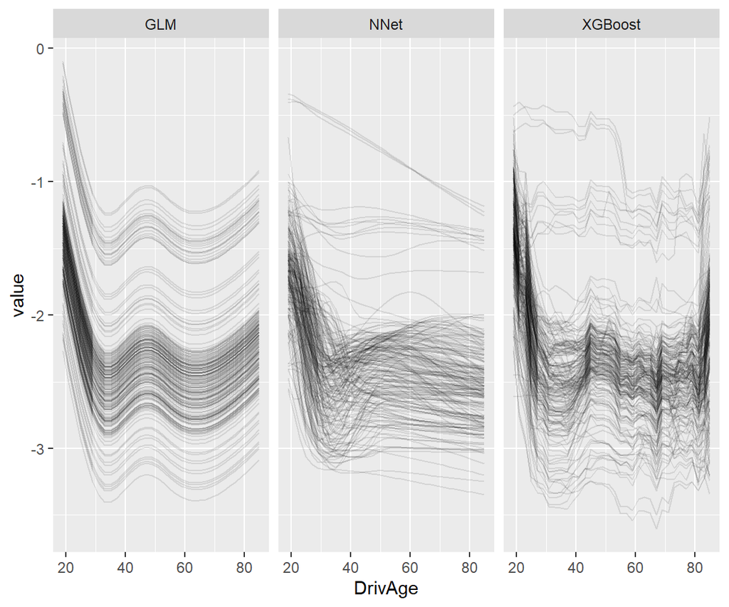

```r
# log-frequency scale (uncentered)
plot(light_ice(fls_log, v = "DrivAge", n_max = 200, seed = 3), alpha = 0.1)
```

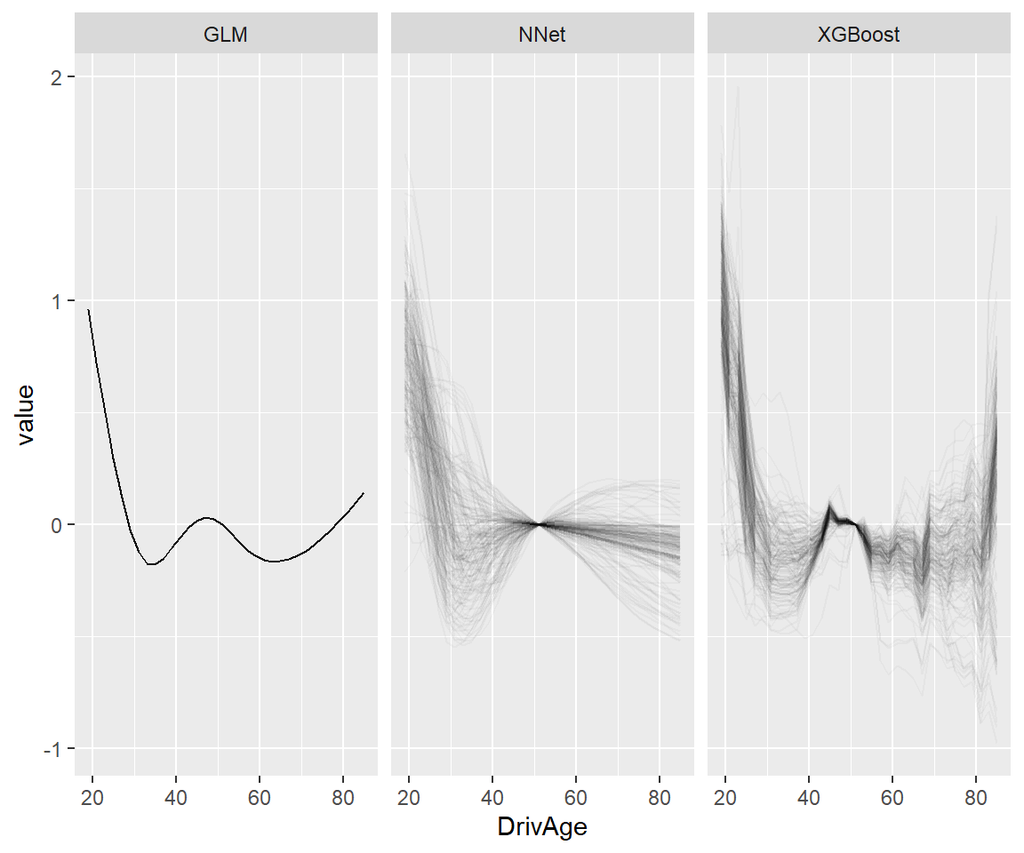

```r
# log-frequency scale (centered)
plot(light_ice(fls_log, v = "DrivAge", n_max = 200, seed = 3,
               center = "middle"), alpha = 0.03)
```

### 5.4.2 Partial dependence curves

Taking the average of many ICE curves produces the famous partial dependence plot. We consider such plots for four predictors.

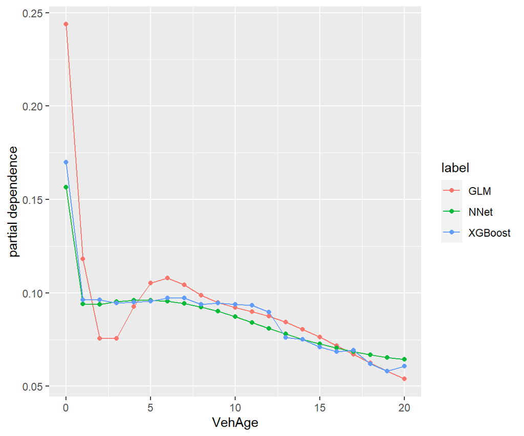

```r
plot(light_profile(fls, v = "VehAge", pd_evaluate_at = 0:20))
```

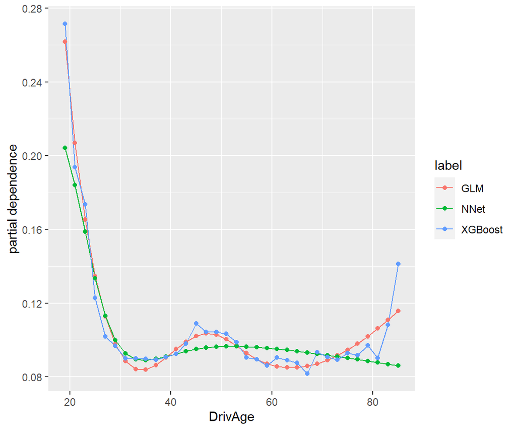

```r
plot(light_profile(fls, v = "DrivAge", n_bins = 25))
```

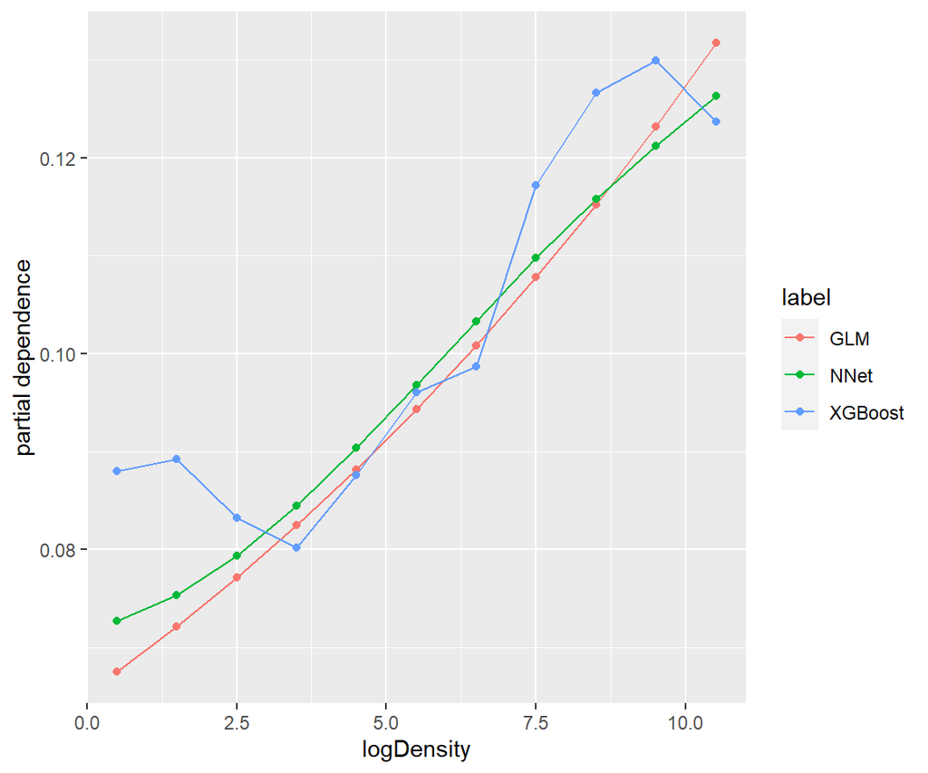

```r
plot(light_profile(fls, v = "logDensity"))
```

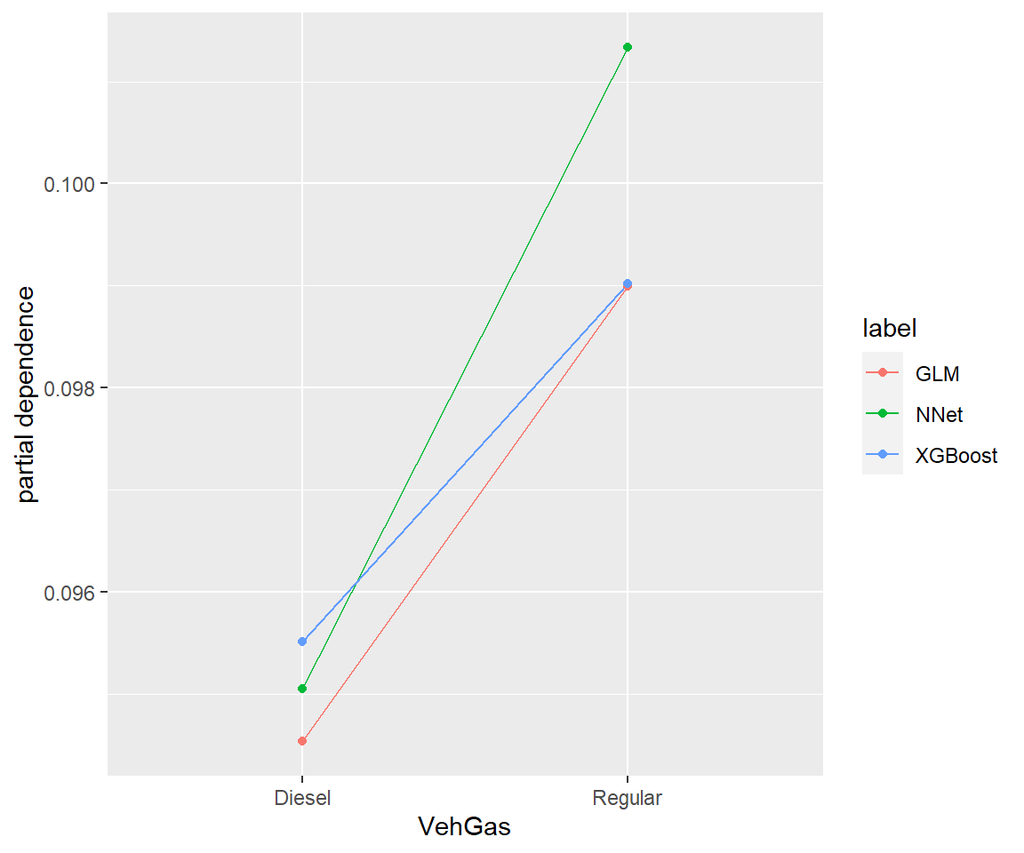

```r
plot(light_profile(fls, v = "VehGas"))
```

### 5.4.3 ALE versus partial dependence

An alternative to the good old partial dependence plots are ALE (accumulated local expectation) plots. They remove the “Ceteris Paribus” assumption of partial dependence plots.

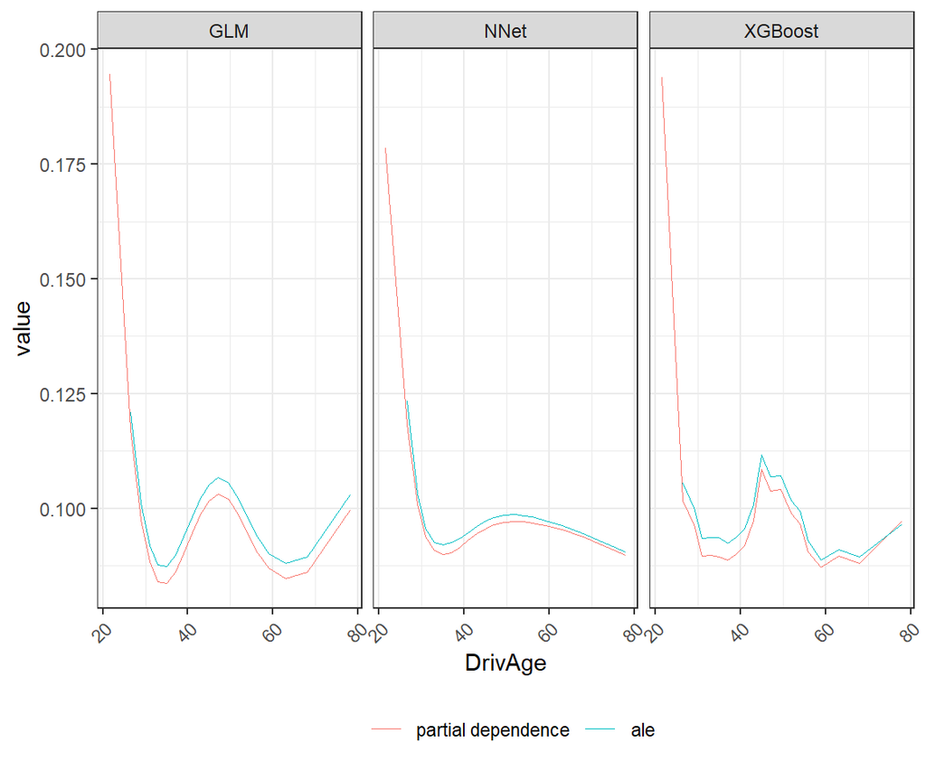

```r
ale_DrivAge <- light_effects(fls, v = "DrivAge", counts_weighted = TRUE,
                             v_labels = FALSE, n_bins = 20, cut_type = "quantile")
plot(ale_DrivAge, use = c("pd", "ale"), show_points = FALSE)
```

### 5.4.4 Classic diagnostic plots

Classic predicted/residual/response versus covariable plots are worth a look.

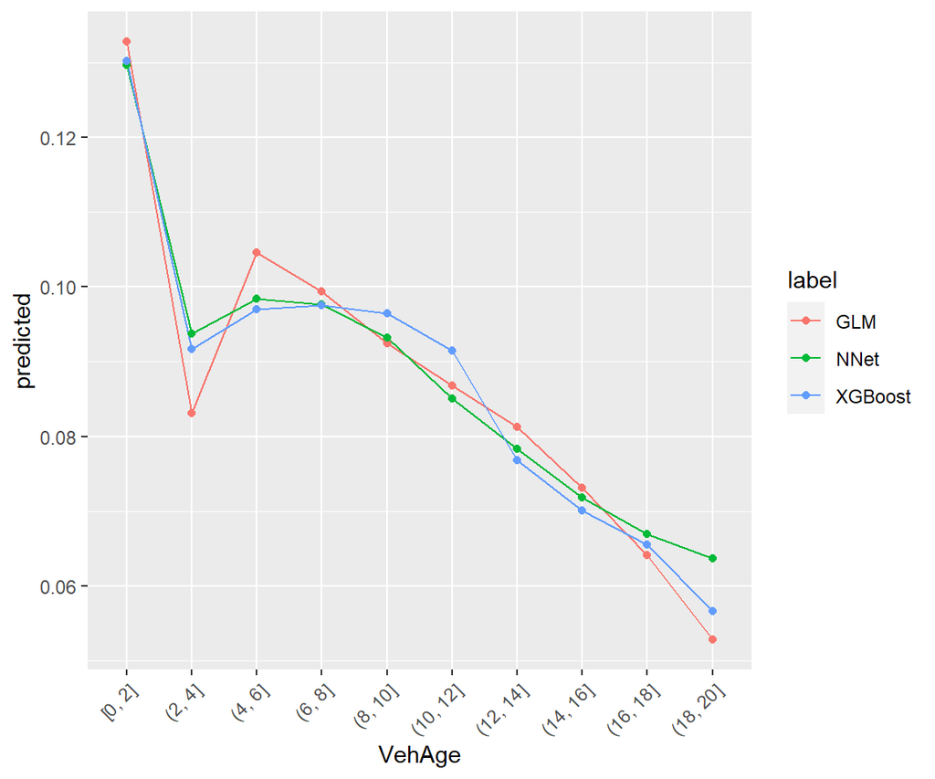

```r
# Average predicted versus covariable
plot(light_profile(fls, v = "VehAge", type = "predicted"))
```

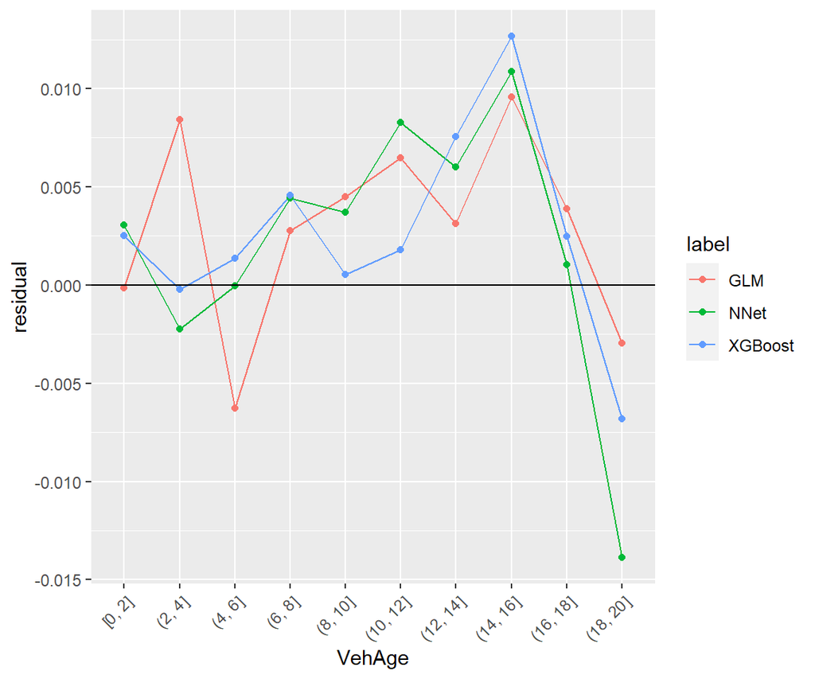

```r
# Average residual versus covariable
plot(light_profile(fls, v = "VehAge", type = "residual")) +
  geom_hline(yintercept = 0)
```

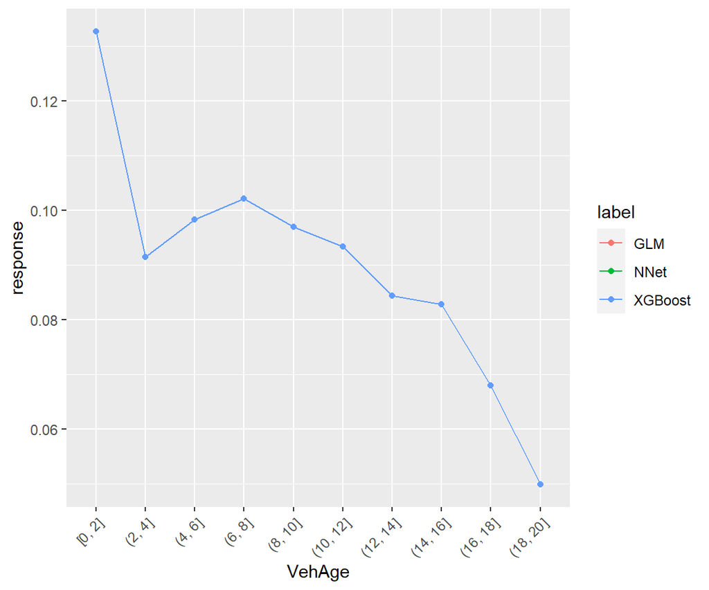

```r
# Average response versus covariable
plot(light_profile(fls, v = "VehAge", type = "response"))
```

### 5.4.5 Multiple aspects combined

We often get a good picture of the effect of a covariable by combining partial dependence with classic plots.

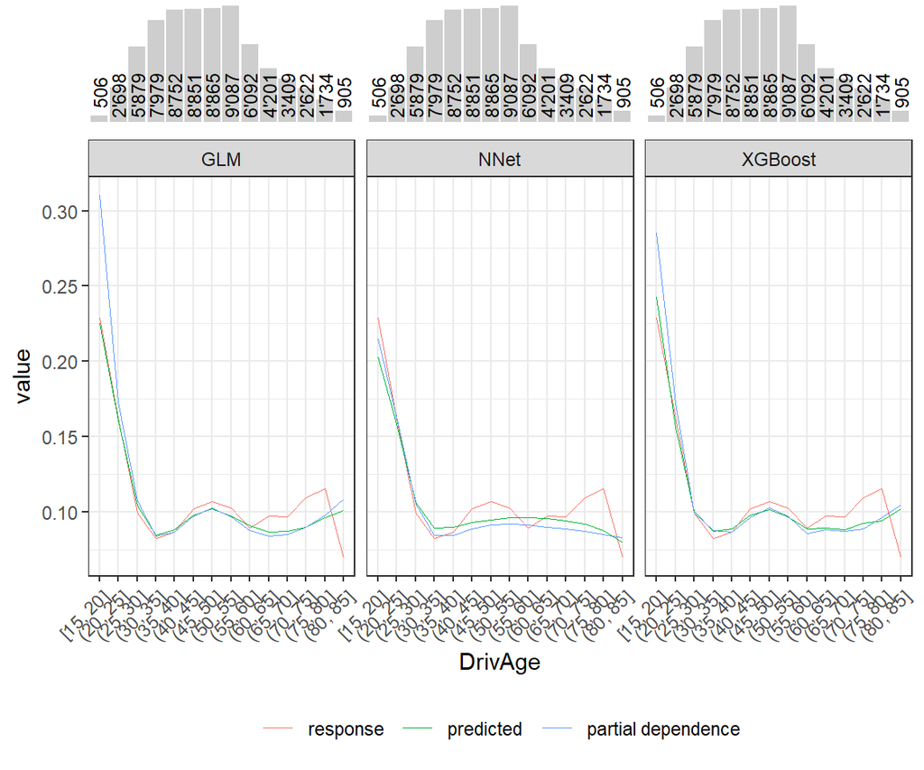

```r
eff_DrivAge <- light_effects(fls, v = "DrivAge", counts_weighted = TRUE)
p <- plot(eff_DrivAge, show_points = FALSE)
plot_counts(p, eff_DrivAge, alpha = 0.3)
```

## 5.5 Interactions

After having studied the effects of single covariables, we now move to the next step: identifying strong interactions. This can be done by looking at Friedman’s H statistic.

### 5.5.1 Relative to importance of involved covariables

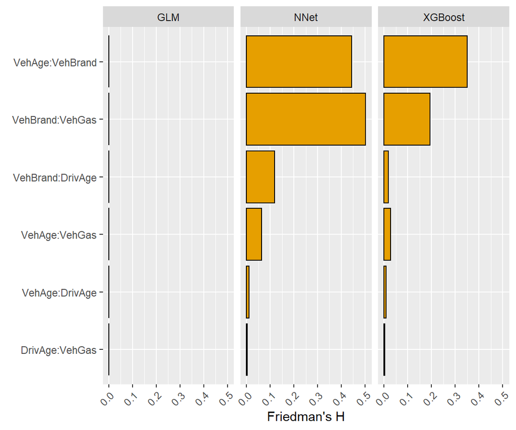

```r
interact_rel <- light_interaction(
  fls_log,
  v = most_important(imp, 4),
  take_sqrt = FALSE,
  pairwise = TRUE,
  use_linkinv = TRUE,
  seed = 61
)
plot(interact_rel, color = "black", fill = fillc, rotate_x = TRUE)
```

### 5.5.2 On absolute scale

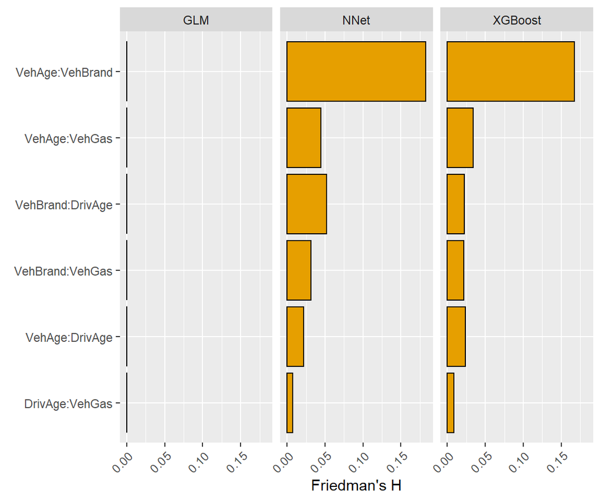

```r
interact_abs <- light_interaction(
  fls_log,
  v = most_important(imp, 4),
  normalize = FALSE,
  pairwise = TRUE,
  use_linkinv = TRUE,
  seed = 61
)
plot(interact_abs, color = "black", fill = fillc, rotate_x = TRUE)
```

### 5.5.3 Visualization

Let’s illustrate a strong and a weak interaction by conditional partial dependence plots.

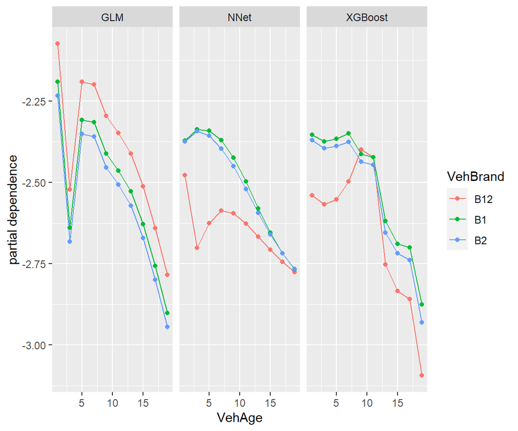

```r
# Filter on largest three brands
sub_data <- test %>%
  filter(VehBrand %in% c("B1", "B2", "B12"))

# Strong interaction
pdp_vehAge_Brand <- light_profile(fls_log, v = "VehAge", by = "VehBrand",
                                  pd_seed = 50, data = sub_data)
plot(pdp_vehAge_Brand)
```

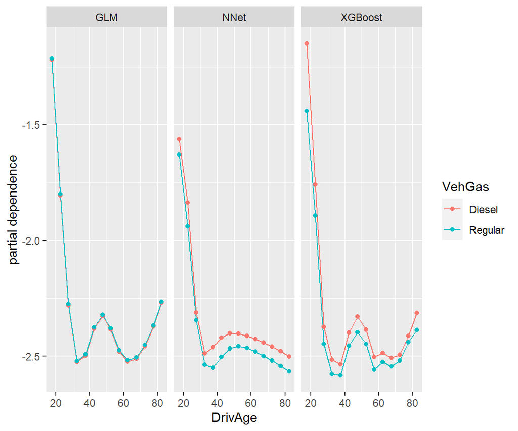

```r
# Weak interaction
pdp_DrivAge_Gas <- light_profile(fls_log, v = "DrivAge",
                                 by = "VehGas", pd_seed = 50)
plot(pdp_DrivAge_Gas)
```

## 5.6 Global surrogate tree

A nice way to interpret a blackbox model is to explain its predictions by a glassbox model like a single decision tree.

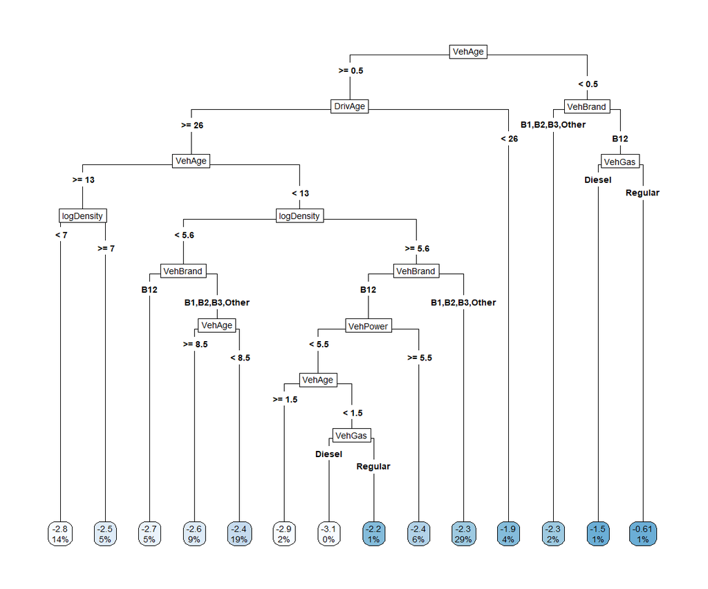

```r
# Neural net
surr_nn <- light_global_surrogate(fls_log$NNet, v = x)
plot(surr_nn)
```

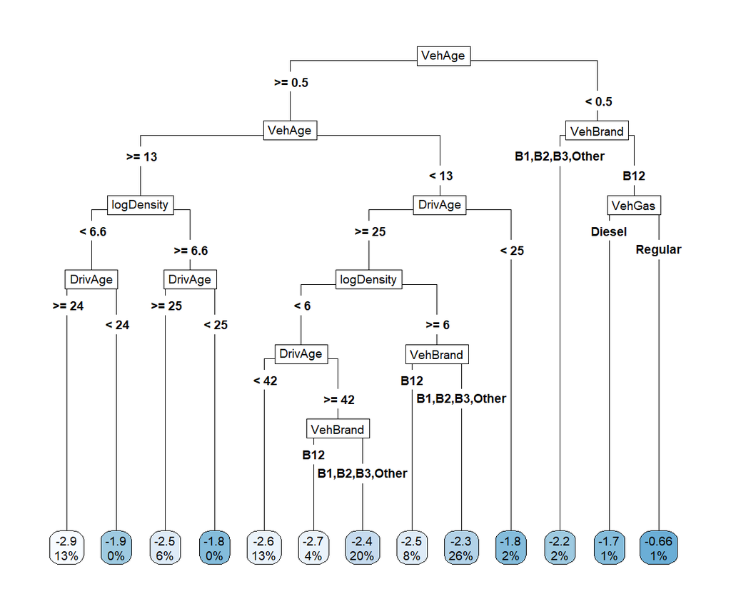

```r
# Boosted trees
surr_xgb <- light_global_surrogate(fls_log$XGBoost, v = x)
plot(surr_xgb)
```

## 5.7 Individual predictions

So far, we have considered global model explanations. What about local properties, i.e. explaining single predictions?

### 5.7.1 Breakdown

One algorithm is called “breakdown”. It decomposes a single prediction into additive contributions from covariables. The first plot shows the standard breakdown decomposition, where variables are visited in the order of importance. The second plot is based on an average of multiple random visit orders. The latter might serve as model agnostic approximation to SHAP.

```r
# The observation/prediction to explain
new_obs <- test[1, ]
new_obs[, x]
```

|  | VehPower | VehAge | VehBrand | VehGas | DrivAge | logDensity | PolicyRegion |
| --- | --- | --- | --- | --- | --- | --- | --- |
| 3 | 6 | 2 | B12 | Diesel | 52 | 3.988984 | R22 |

```r
unlist(predict(fls, data = new_obs))
```

```
##      GLM.3     NNet.1    XGBoost
## 0.07692262 0.06372208 0.08053540
```

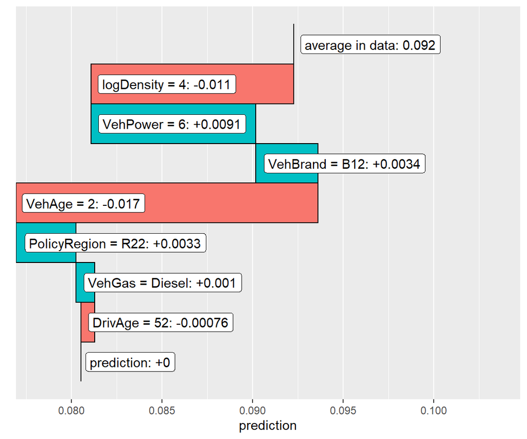

```r
# Breakdown
bd <- light_breakdown(fls$XGBoost, new_obs = new_obs,
                      v = x, n_max = 1000, seed = 20)
plot(bd)
```

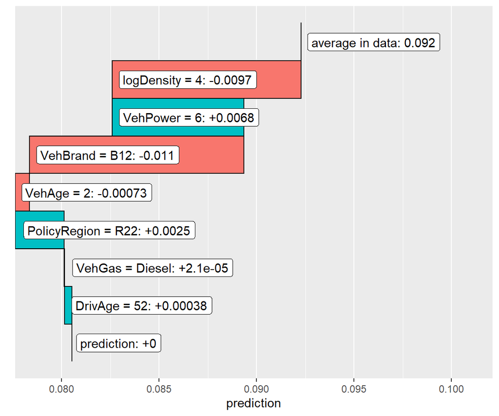

```r
# Extract same order of variables for visualization only
v <- setdiff(bd$data$variable, c("baseline", "prediction"))

# Approximate SHAP
shap <- light_breakdown(fls$XGBoost, new_obs,
                        visit_strategy = "permutation",
                        v = v, n_max = 1000, seed = 20)
plot(shap)
```

## 5.8 Derive global model properties from local

Above decompositions explain single predictions, not the model as a whole. By decomposing many predictions, we can even make global model statements just by a descriptive analysis of many single contibutions. Note there are better ways to calculate SHAP values than by repeated calls of breakdown.

Attention: This takes a looooong time to calculate (15 minutes on my computer). That is why we save the resulting explainer and reload it in subsequent runs.

We derive SHAP importance and SHAP dependence plots. SHAP importance show average absolute contributions per covariable, while SHAP dependence plots are scatter plots of contributions against covariable values.

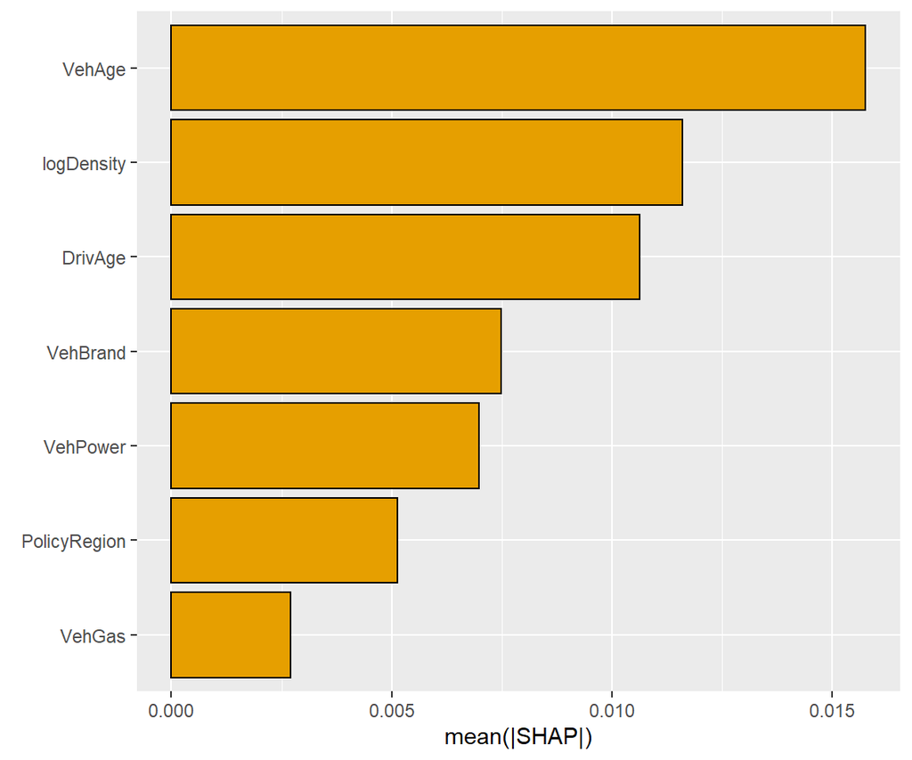

```r
if (!file.exists("fl_with_shap.rds")) {
  fl_with_shap <- add_shap(
    fls$XGBoost,
    v = x,
    n_shap = 500,
    verbose = FALSE,
    n_perm = 12,
    n_max = 1000,
    seed = 100
  )
  saveRDS(fl_with_shap, file = "fl_with_shap.rds")
} else {
  fl_with_shap <- readRDS("fl_with_shap.rds")
}

# SHAP importance
plot(light_importance(fl_with_shap, v = x, type = "shap"),
     fill = fillc, color = "black")
```

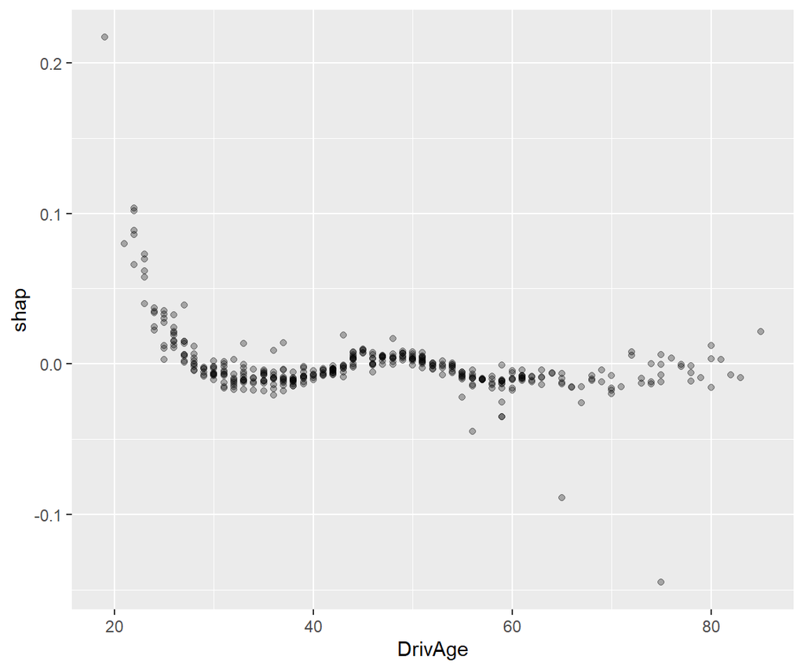

```r
# SHAP dependence plot
plot(light_scatter(fl_with_shap, v = "DrivAge", type = "shap"), alpha = 0.3)
```